# ISyE 6525 HW3 — Question 4: Tucker Compression and Hard Thresholding

This notebook implements Tucker decomposition with HOSVD initialization and Tucker ALS/HOOI from scratch, without calling `tucker_als` or an equivalent decomposition routine.

## Deliverables

- **Q4(a)** For $R_1=R_2=R$, $R_3=\min(R,40)$, and $$ R\in\{2,4,6,8,10,15,20,25,30,40\}, $$ report relative reconstruction error and compression ratio. Plot error versus $R$ and versus compression ratio.
- **Q4(b)** Prove the orthonormal-factor error identity and verify it numerically for ranks $(30,30,20)$.
- **Q4(c)** With ranks $(30,30,20)$, keep only the largest 10%, 20%, 30%, 40%, and 50% of core coefficients by absolute value. Report errors and display reconstructed frames 5, 15, and 30.

The dataset `Question4.mat` contains $\mathcal X\in\mathbb R^{64\times64\times40}$.

```python
from pathlib import Path

import numpy as np
import matplotlib.pyplot as plt
from scipy.io import loadmat

np.set_printoptions(precision=6, suppress=True)

DATA_PATH = Path("Question4.mat")
R_VALUES = [2, 4, 6, 8, 10, 15, 20, 25, 30, 40]
MAX_ITER = 200
TOL = 1e-8
```

## 1. Load and inspect the infrared tensor

```python
mat = loadmat(DATA_PATH)
print("MAT keys:", [k for k in mat.keys() if not k.startswith("__")])

X = np.asarray(mat["X"], dtype=float)
assert X.shape == (64, 64, 40), X.shape
```

```
MAT keys: ['X']
```

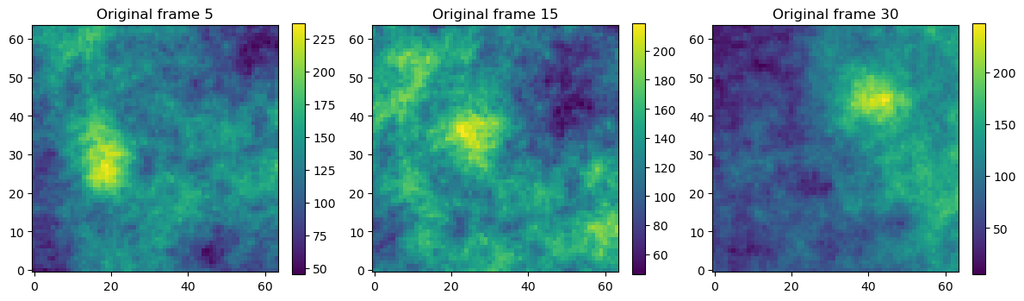

```python
frame_indices = [4, 14, 29] # numpy is 0-index
fig, axes = plt.subplots(1, 3, figsize=(12, 3.5))
for ax, k in zip(axes, frame_indices):
    im = ax.imshow(X[:, :, k], origin="lower")
    ax.set_title(f"Original frame {k+1}")
    fig.colorbar(im, ax=ax, fraction=0.046)
plt.tight_layout()
```

## 2. Tensor primitives

Tucker decomposition repeatedly applies matrices along tensor modes, so implement and test these before ALS:

1. `unfold(X, mode)`
2. `mode_dot(X, M, mode)`
3. `tucker_reconstruct(core, factors)`

If $$ Y = X\times_n M, $$ and $X$ has mode-$n$ length $I_n$, then $M$ should have shape $(J,I_n)$, and the resulting tensor has mode-$n$ length $J$.

```python
def unfold(X: np.ndarray, mode: int) -> np.ndarray:
    """Mode-n unfolding: requested mode becomes rows."""
    return np.moveaxis(X, mode, 0).reshape(X.shape[mode], -1)


def mode_dot(X: np.ndarray, M: np.ndarray, mode: int) -> np.ndarray:
    """Compute X ×_mode M.

    M.shape must be (new_mode_size, X.shape[mode]).

    """
    moved_tensor = np.moveaxis(X, mode, 0)
    moved_result = np.einsum('ij,j...->i...', M, moved_tensor)  # Einstein summation for mode-n product
    return np.moveaxis(moved_result, 0, mode)


def multi_mode_dot(X: np.ndarray, matrices: list[np.ndarray]) -> np.ndarray:
    """Apply one matrix along each mode in order."""
    Y = X
    for mode, M in enumerate(matrices):
        Y = mode_dot(Y, M, mode)
    return Y


def tucker_reconstruct(core: np.ndarray, factors: list[np.ndarray]) -> np.ndarray:
    """G ×1 U1 ×2 U2 ×3 U3."""
    return multi_mode_dot(core, factors)
```

### 2.1 Shape tests

Use tiny arrays before the real dataset.

For $X\in\mathbb R^{2\times3\times4}$ and $M\in\mathbb R^{5\times3}$, $$ X\times_2 M $$ should have shape $2\times5\times4$.

Also test that multiplying by identity matrices reproduces the original tensor.

```python
X_test = np.arange(2*3*4, dtype=float).reshape(2, 3, 4)
M = np.arange(5*3, dtype=float).reshape(5, 3)
Y_test = mode_dot(X_test, M, mode=1)
assert Y_test.shape == (2, 5, 4)

X_identity = multi_mode_dot(
    X_test,
    [np.eye(2), np.eye(3), np.eye(4)],
)
assert np.allclose(X_identity, X_test)
```

## 3. HOSVD initialization

The lecture initializes Tucker ALS with HOSVD.

For each mode $k$:

1. Form $X_{(k)}$.
2. Compute its SVD.
3. Keep the first $R_k$ **left singular vectors** as $U^{(k)}$.

Then compute the initial core $$ \mathcal G = \mathcal X \times_1 U^{(1)\top} \times_2 U^{(2)\top} \times_3 U^{(3)\top}. $$

Each factor matrix should be column-wise orthonormal.

```python
def hosvd_init(X: np.ndarray, ranks: tuple[int, int, int]):
    """Return HOSVD factor matrices U^(1), U^(2), U^(3)."""
    factors = []
    for mode, R in enumerate(ranks):
        Xn = unfold(X, mode)
        U, s, Vt = np.linalg.svd(Xn, full_matrices=False)
        factors.append(U[:, :R])
    return factors


def tucker_core(X: np.ndarray, factors: list[np.ndarray]) -> np.ndarray:
    """Project X onto the factor subspaces."""
    # Apply U.T along each mode sequentially, because of associativity of mode-n products.
    core = X
    for mode, U in enumerate(factors):
        core = mode_dot(core, U.T, mode)
    return core
```

## 4. Tucker ALS / HOOI update

The lecture's ALS step for mode $k$ is:

1. Project $X$ along **all other modes** using their transposed factor matrices.
2. Leave mode $k$ unprojected.
3. Unfold the resulting tensor along mode $k$.
4. Set $U^{(k)}$ to the leading $R_k$ left singular vectors.
5. Repeat for all modes until convergence.

A convenient objective to monitor is the squared core norm $$ \|\mathcal G\|_F^2, $$ because with orthonormal factors, maximizing captured core energy is equivalent to minimizing reconstruction error.

```python
def tucker_als(
    X: np.ndarray,
    ranks: tuple[int, int, int],
    *,
    max_iter: int = MAX_ITER,
    tol: float = TOL,
    verbose: bool = False,
):
    """Tucker ALS initialized by HOSVD.

    Returns
    -------
    core
    factors
    history

    """
    factors = hosvd_init(X, ranks)
    history = {"core_energy": []}

    for iteration in range(max_iter):
        for mode, R in enumerate(ranks):
            # Start from X
            X_proj = X
            # Project along every mode j != k using Uj.T
            for j, U in enumerate(factors):
                if j != mode:
                    X_proj = mode_dot(X_proj, U.T, j)
            # Unfold the projected tensor along mode k
            Xn = unfold(X_proj, mode)
            # SVD that unfolding
            U, s, Vt = np.linalg.svd(Xn, full_matrices=False)
            # Keep the first R_k left singular vectors as Uk
            factors[mode] = U[:, :R]

        # Recompute the core after each complete sweep
        core = tucker_core(X, factors)
        core_energy = np.linalg.norm(core)**2 # squared Frobenius norm as objective
        history["core_energy"].append(core_energy)

        # Stop on small relative change
        if iteration > 0:
            rel_change = abs(history["core_energy"][-1] - history["core_energy"][-2]) / history["core_energy"][-2]
            if rel_change < tol:
                break

    return core, factors, history
```

## 5. Validate Tucker ALS before the rank sweep

Checks:

- Factor shapes are $(I_k,R_k)$.
- $U_k^\top U_k\approx I$.
- Core shape equals `ranks`.
- Reconstructed tensor has the same shape as $X$.
- Captured core energy should not decrease materially across complete ALS sweeps.

```python
def relative_error(X, X_hat):
    return np.linalg.norm(X - X_hat) / np.linalg.norm(X)


def check_orthonormal(factors, atol=1e-8):
    for mode, U in enumerate(factors):
        gram = U.T @ U
        assert np.allclose(gram, np.eye(U.shape[1]), atol=atol), (
            f"Mode {mode} factor is not orthonormal"
        )
```

```
core shape: (4, 4, 4)
relative error: 0.1527771735434373
```

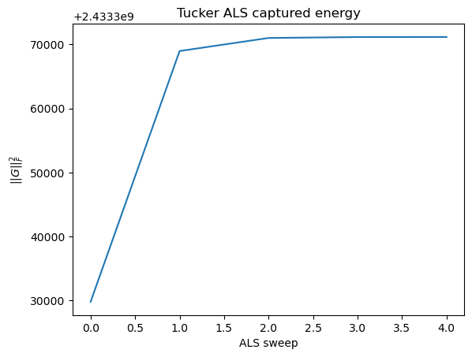

```python
core, factors, history = tucker_als(X, ranks=(4, 4, 4))
check_orthonormal(factors)
X_hat = tucker_reconstruct(core, factors)
print("core shape:", core.shape)
print("relative error:", relative_error(X, X_hat))
plt.plot(history["core_energy"])
plt.xlabel("ALS sweep")
plt.ylabel(r"$||G||_F^2$")
plt.title("Tucker ALS captured energy")
plt.show()
```

## 6. Q4(a): rank sweep, reconstruction error, compression ratio

For each $$ R\in\{2,4,6,8,10,15,20,25,30,40\}, $$ use $$ (R_1,R_2,R_3)=(R,R,\min(R,40)). $$

The relative error is $$ \epsilon=\frac{\|X-\hat X\|_F}{\|X\|_F}. $$

The assignment defines compression ratio as

$$ \text{compression ratio} = \frac{\text{number of entries in }X} {\text{entries in core}+\text{entries in all three factor matrices}}. $$

For dimensions $(I,J,K)$ and ranks $(R_1,R_2,R_3)$, the stored entry count is

$$ R_1R_2R_3 + IR_1 + JR_2 + KR_3. $$

```python
def compression_ratio(shape, ranks):
    I, J, K = shape
    R1, R2, R3 = ranks
    original = I * J * K
    stored = R1 * R2 * R3 + I * R1 + J * R2 + K * R3
    return original / stored


sweep = []
fits = {}

for R in R_VALUES:
    ranks = (R, R, min(R, 40))
    core, factors, history = tucker_als(X, ranks)
    X_hat = tucker_reconstruct(core, factors)
    err = relative_error(X, X_hat)
    cr = compression_ratio(X.shape, ranks)

    sweep.append({"R": R, "ranks": ranks, "error": err, "compression_ratio": cr})
    fits[ranks] = {"core": core, "factors": factors, "history": history}

for row in sweep:
    print(row)
```

```
{'R': 2, 'ranks': (2, 2, 2), 'error': np.float64(0.18169932210197595), 'compression_ratio': 476.27906976744185}
{'R': 4, 'ranks': (4, 4, 4), 'error': np.float64(0.1527771735434373), 'compression_ratio': 222.6086956521739}
{'R': 6, 'ranks': (6, 6, 6), 'error': np.float64(0.1320017492643692), 'compression_ratio': 133.8562091503268}
{'R': 8, 'ranks': (8, 8, 8), 'error': np.float64(0.11643991791530707), 'compression_ratio': 88.27586206896552}
{'R': 10, 'ranks': (10, 10, 10), 'error': np.float64(0.10665719781206222), 'compression_ratio': 61.134328358208954}
{'R': 15, 'ranks': (15, 15, 15), 'error': np.float64(0.08897404219154112), 'compression_ratio': 27.793044953350297}
{'R': 20, 'ranks': (20, 20, 20), 'error': np.float64(0.07604184624028555), 'compression_ratio': 14.422535211267606}
{'R': 25, 'ranks': (25, 25, 25), 'error': np.float64(0.06473803870088067), 'compression_ratio': 8.264312736443884}
{'R': 30, 'ranks': (30, 30, 30), 'error': np.float64(0.0532214335227006), 'compression_ratio': 5.1136079900124844}
{'R': 40, 'ranks': (40, 40, 40), 'error': np.float64(0.03326413774818972), 'compression_ratio': 2.316742081447964}
```

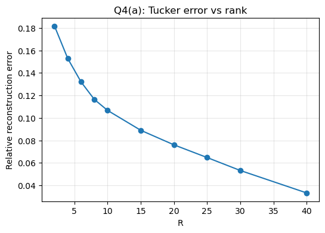

```python
plt.figure(figsize=(6, 4))
plt.plot([d["R"] for d in sweep], [d["error"] for d in sweep], marker="o")
plt.xlabel("R")
plt.ylabel("Relative reconstruction error")
plt.title("Q4(a): Tucker error vs rank")
plt.grid(alpha=0.3)
plt.show()
```

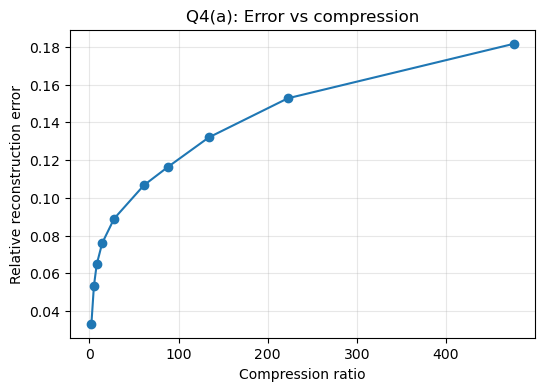

```python
plt.figure(figsize=(6, 4))
plt.plot(
    [d["compression_ratio"] for d in sweep],
    [d["error"] for d in sweep],
    marker="o",
)
plt.xlabel("Compression ratio")
plt.ylabel("Relative reconstruction error")
plt.title("Q4(a): Error vs compression")
plt.grid(alpha=0.3)
plt.show()
```

## 7. Q4(b): orthonormal-factor error identity

We need to show $$ \epsilon = \frac{\sqrt{\|X\|_F^2-\|G\|_F^2}}{\|X\|_F}. $$

### Proof

Let the Tucker factor matrices have orthonormal columns: $$ U^{(n)\top}U^{(n)}=I. $$ For fixed factors, define the multilinear subspace $$ \mathcal S = \operatorname{span}\left\{ u_p^{(1)}\circ u_q^{(2)}\circ u_r^{(3)} \right\}_{p,q,r}. $$ Because the columns of each factor matrix are orthonormal, these rank-one basis tensors are also orthonormal under the Frobenius inner product: $$ \left\langle u_p^{(1)}\circ u_q^{(2)}\circ u_r^{(3)}, u_{p'}^{(1)}\circ u_{q'}^{(2)}\circ u_{r'}^{(3)} \right\rangle_F = \delta_{pp'}\delta_{qq'}\delta_{rr'}. $$

The core $$ G=X\times_1 U^{(1)\top}\times_2 U^{(2)\top}\times_3 U^{(3)\top} $$ contains the coordinates of $X$ in this orthonormal Tucker basis. Reconstructing, $$ \hat X = G\times_1 U^{(1)}\times_2 U^{(2)}\times_3 U^{(3)}, $$ therefore gives the orthogonal projection of $X$ onto $\mathcal S$. Hence the residual $X-\hat X$ is orthogonal to $\hat X$: $$ \langle X-\hat X,\hat X\rangle_F=0. $$ By the Pythagorean theorem, $$ \|X\|_F^2 = \|X-\hat X\|_F^2+\|\hat X\|_F^2. $$

It remains to relate $\|\hat X\|_F$ to $\|G\|_F$. Vectorizing the Tucker reconstruction gives $$ \operatorname{vec}(\hat X) = \left(U^{(3)}\otimes U^{(2)}\otimes U^{(1)}\right)\operatorname{vec}(G). $$ The Kronecker product also has orthonormal columns because $$ \left(U^{(3)}\otimes U^{(2)}\otimes U^{(1)}\right)^\top \left(U^{(3)}\otimes U^{(2)}\otimes U^{(1)}\right) = I. $$ Therefore multiplication by this matrix preserves the Euclidean norm of the core coordinates, so $$ \|\hat X\|_F=\|G\|_F. $$

Substituting into the Pythagorean identity gives $$ \|X-\hat X\|_F^2 = \|X\|_F^2-\|G\|_F^2. $$ Taking square roots and dividing by $\|X\|_F$ yields $$ \boxed{ \epsilon = \frac{\sqrt{\|X\|_F^2-\|G\|_F^2}}{\|X\|_F} }. $$

The next cell verifies this identity numerically for ranks $(30,30,20)$.

```python
target_ranks = (30, 30, 20)
if target_ranks in fits:
    fit_3020 = fits[target_ranks]
    core_3020 = fit_3020["core"]
    factors_3020 = fit_3020["factors"]
else:
    core_3020, factors_3020, _ = tucker_als(X, target_ranks)

check_orthonormal(factors_3020)
X_hat_3020 = tucker_reconstruct(core_3020, factors_3020)

lhs = relative_error(X, X_hat_3020)
rhs = np.sqrt(
    max(np.linalg.norm(X)**2 - np.linalg.norm(core_3020)**2, 0.0)
) / np.linalg.norm(X)

print("direct relative error:", lhs)
print("energy-identity value:", rhs)
print("absolute difference:", abs(lhs - rhs))
```

```
direct relative error: 0.07113053251962104
energy-identity value: 0.07113053251961327
absolute difference: 7.771561172376096e-15
```

## 8. Q4(c): hard threshold the $(30,30,20)$ core

For each keep fraction $$ p\in\{0.10,0.20,0.30,0.40,0.50\}, $$ retain the $p$ fraction of core coefficients with **largest absolute value** and set all others to zero.

### Implementation details

- If the core has $N$ entries, choose exactly (or clearly define how you round) $pN$ entries.
- Rank by $|g_i|$, not by signed value.
- Keep the factor matrices fixed; only threshold the core.
- Reconstruct from the thresholded core.
- Report relative error.
- Display frames **5, 15, 30** -> Python indices **4, 14, 29**.
- Also compute retained core energy $\|G_{thr}\|_F^2/\|G\|_F^2$; it makes the final interpretation much easier.

```python
def hard_threshold_core(core: np.ndarray, keep_fraction: float) -> np.ndarray:
    # Keep the requested fraction of coefficients with largest absolute value.
    flat_core = core.flatten()
    k = int(np.ceil(keep_fraction * flat_core.size))
    idx = np.argpartition(np.abs(flat_core), -k)[-k:]
    mask = np.zeros_like(flat_core, dtype=bool)
    mask[idx] = True
    flat_core[~mask] = 0
    return flat_core.reshape(core.shape)
```

```python
KEEP_FRACTIONS = [0.10, 0.20, 0.30, 0.40, 0.50]

# threshold, reconstruct, and collect results.
threshold_results = []

for frac in KEEP_FRACTIONS:
    G_thr = hard_threshold_core(core_3020, frac)
    X_thr = tucker_reconstruct(G_thr, factors_3020)
    err = relative_error(X, X_thr)
    energy_fraction = np.linalg.norm(G_thr)**2 / np.linalg.norm(core_3020)**2

    threshold_results.append({
        "keep_fraction": frac,
        "relative_error": err,
        "core_energy_fraction": energy_fraction,
        "X_hat": X_thr,
    })

for row in threshold_results:
    print(
        f"keep={row['keep_fraction']:.0%}, "
        f"error={row['relative_error']:.6f}, "
        f"core energy retained={row['core_energy_fraction']:.6f}"
    )
```

```
keep=10%, error=0.082414, core energy retained=0.998259
keep=20%, error=0.076965, core energy retained=0.999131
keep=30%, error=0.074454, core energy retained=0.999514
keep=40%, error=0.073015, core energy retained=0.999727
keep=50%, error=0.072139, core energy retained=0.999855
```

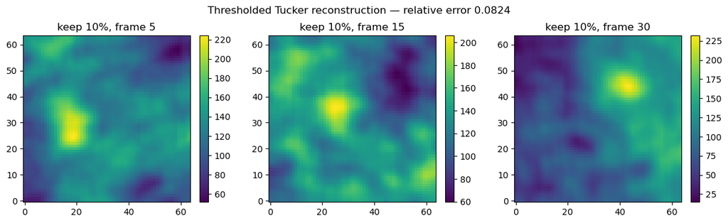

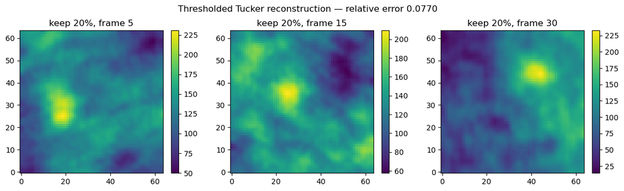

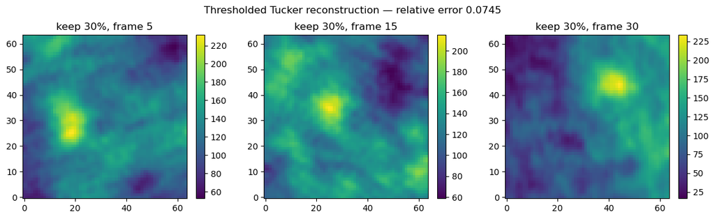

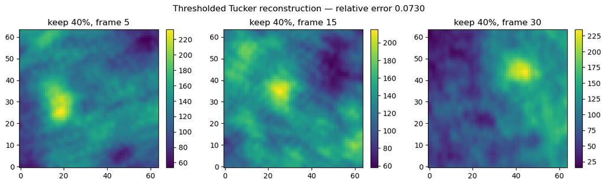

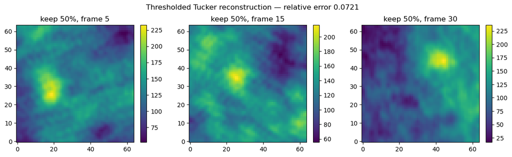

```python
# display reconstructed frames 5, 15, 30 for every threshold level.

frame_indices = [4, 14, 29]

for row in threshold_results:
    X_thr = row["X_hat"]
    frac = row["keep_fraction"]

    fig, axes = plt.subplots(1, 3, figsize=(12, 3.5))
    for ax, k in zip(axes, frame_indices):
        im = ax.imshow(X_thr[:, :, k], origin="lower")
        ax.set_title(f"keep {frac:.0%}, frame {k+1}")
        fig.colorbar(im, ax=ax, fraction=0.046)
    fig.suptitle(
        f"Thresholded Tucker reconstruction — relative error {row['relative_error']:.4f}"
    )
    plt.tight_layout()
    plt.show()
```

## 9. Q4(c) interpretation

The hard-thresholding results show that the Tucker core energy is **highly concentrated in a small fraction of coefficients**.

| Core coefficients retained | Relative error | Core energy retained |
| --- | --- | --- |
| 10% | 0.082414 | 99.8259% |
| 20% | 0.076965 | 99.9131% |
| 30% | 0.074454 | 99.9514% |
| 40% | 0.073015 | 99.9727% |
| 50% | 0.072139 | 99.9855% |

The unthresholded $(30,30,20)$ Tucker model has relative error approximately $0.071131$. Keeping only the largest 10% of the 18,000 core coefficients increases the error only to about $0.0824$ while retaining about **99.83% of the core energy**. Increasing the retained fraction from 10% to 50% produces only a modest additional reduction in error, from $0.0824$ to $0.0721$, showing clear diminishing returns.

The reconstructed frames also preserve the dominant hot and cold regions and the main spatial structure even at the 10% threshold. As more coefficients are retained, finer local variation and texture are restored, while the large-scale structure changes much less.

Therefore the core is strongly compressible: a relatively small set of large-magnitude coefficients contains almost all of the energy represented by the $(30,30,20)$ Tucker model, while most of the remaining coefficients have small individual contributions. This is exactly the setting in which hard thresholding provides substantial coefficient reduction with limited additional reconstruction error.